# Time series seminar

A&B

Maj 2022

1. Narišite graf in komentirajte, ali se iz njega vidi kakšen trend ali sezonskost.

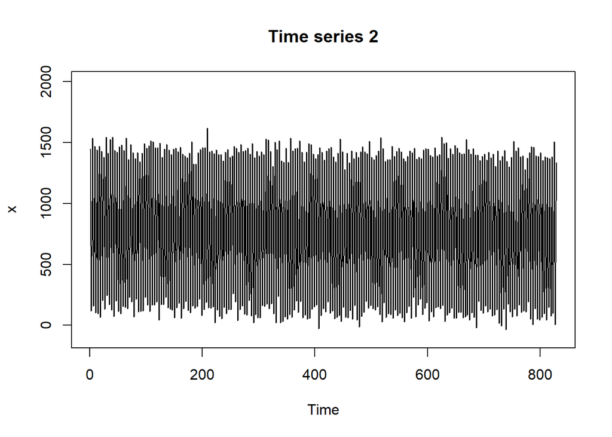

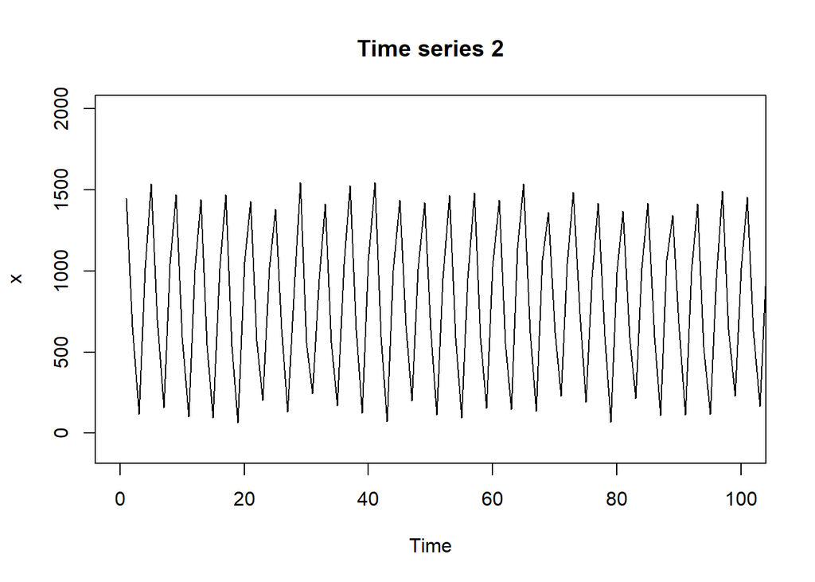

```
## [1] "Ne opazimo trenda, opazimo pa sezonskost."
```

2. Odstranite morebiten trend in sezonskost z metodami, uporabljenimi pri tečaju: (zaporedno) diferenciranje, logaritmiranje, neposredna ocena sezonskih komponent, polinomski trend stopnje največ 3 ali prileganje periodične funkcije (ali kakšna kombinacija teh metod). Potem ko odstranite morebiten trend, narišite tudi surovi in zglajeni periodogram ter komentirajte, ali se vidi kakšna sezonskost in kakšna naj bi bila perioda.

REŠEVANJE: logaritmiranja ne moremo uporabiti, ker imamo negativne podatke diferenciranje:

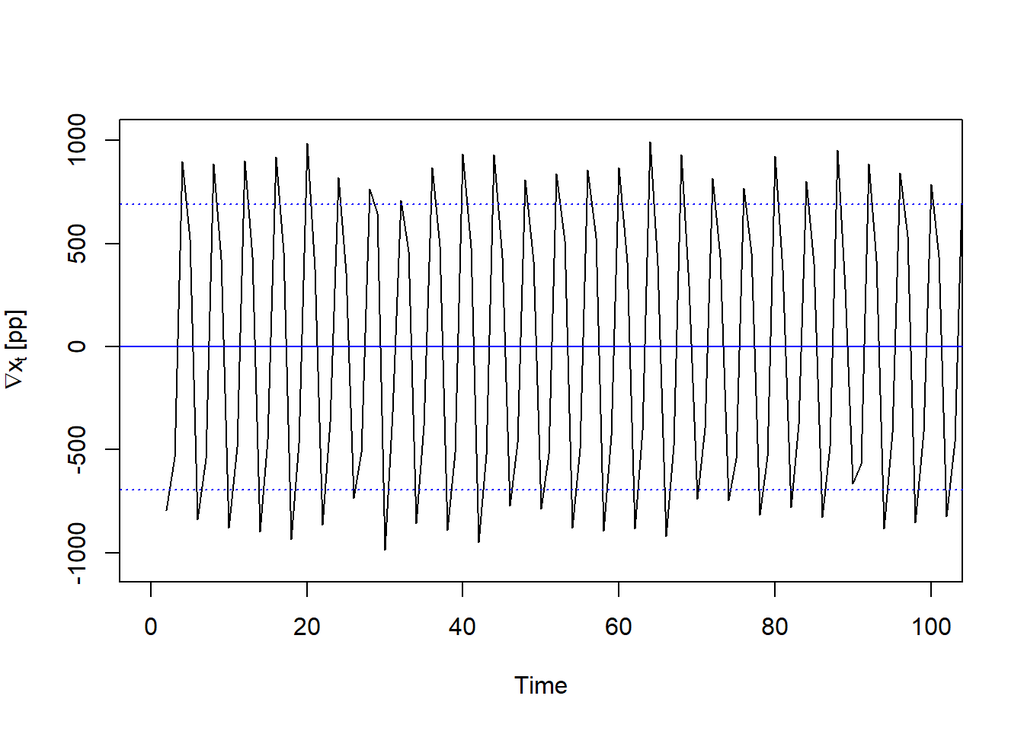

```
##
## Call:
## lm(formula = x ~ I(sin(perioda * t)) + I(cos(perioda * t)) +
##     I(sin(perioda2 * t)) + I(cos(perioda2 * t)))
##
## Residuals:
##     Min      1Q  Median      3Q     Max
## -583.92 -146.58   -7.66  145.46  545.64
##
## Coefficients:
##                      Estimate Std. Error t value Pr(>|t|)
## (Intercept)          770.8550     7.6106 101.287   <2e-16 ***
## I(sin(perioda * t))  287.0049    10.7703  26.648   <2e-16 ***
## I(cos(perioda * t))  550.2589    10.7703  51.090   <2e-16 ***
## I(sin(perioda2 * t))  18.6738    10.7656   1.735   0.0832 .
## I(cos(perioda2 * t))  -0.4413    10.7751  -0.041   0.9673
## ---
## Signif. codes:  0 '***' 0.001 '**' 0.01 '*' 0.05 '.' 0.1 ' ' 1
##
## Residual standard error: 219.1 on 824 degrees of freedom
## Multiple R-squared:  0.8012, Adjusted R-squared:  0.8002
## F-statistic: 830.1 on 4 and 824 DF,  p-value: < 2.2e-16
```

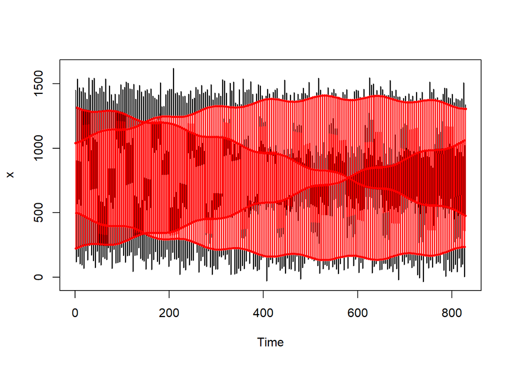

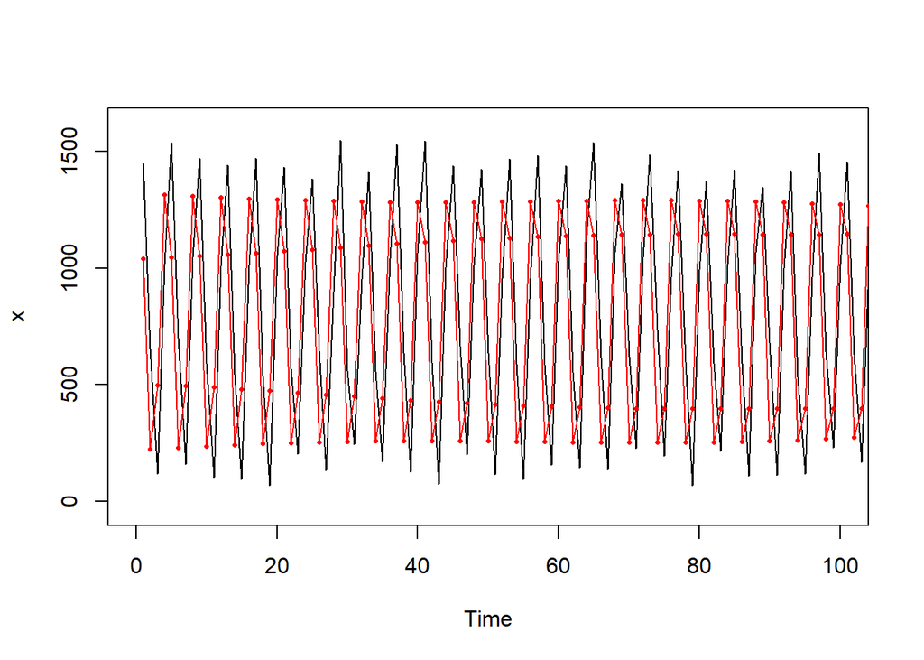

```
##
## Call:
## lm(formula = d ~ I(sin(perioda * t)) + I(cos(perioda * t)))
##
## Residuals:
##      Min       1Q   Median       3Q      Max
## -204.725  -50.142   -0.614   49.743  226.055
##
## Coefficients:
##                     Estimate Std. Error t value Pr(>|t|)
## (Intercept)          -0.1355     2.5258  -0.054    0.957
## I(sin(perioda * t)) 450.9594     3.5720 126.247   <2e-16 ***
## I(cos(perioda * t)) 862.4393     3.5720 241.442   <2e-16 ***
## ---
## Signif. codes:  0 '***' 0.001 '**' 0.01 '*' 0.05 '.' 0.1 ' ' 1
##
## Residual standard error: 72.68 on 825 degrees of freedom
## Multiple R-squared:  0.989,  Adjusted R-squared:  0.989
## F-statistic: 3.712e+04 on 2 and 825 DF,  p-value: < 2.2e-16
```

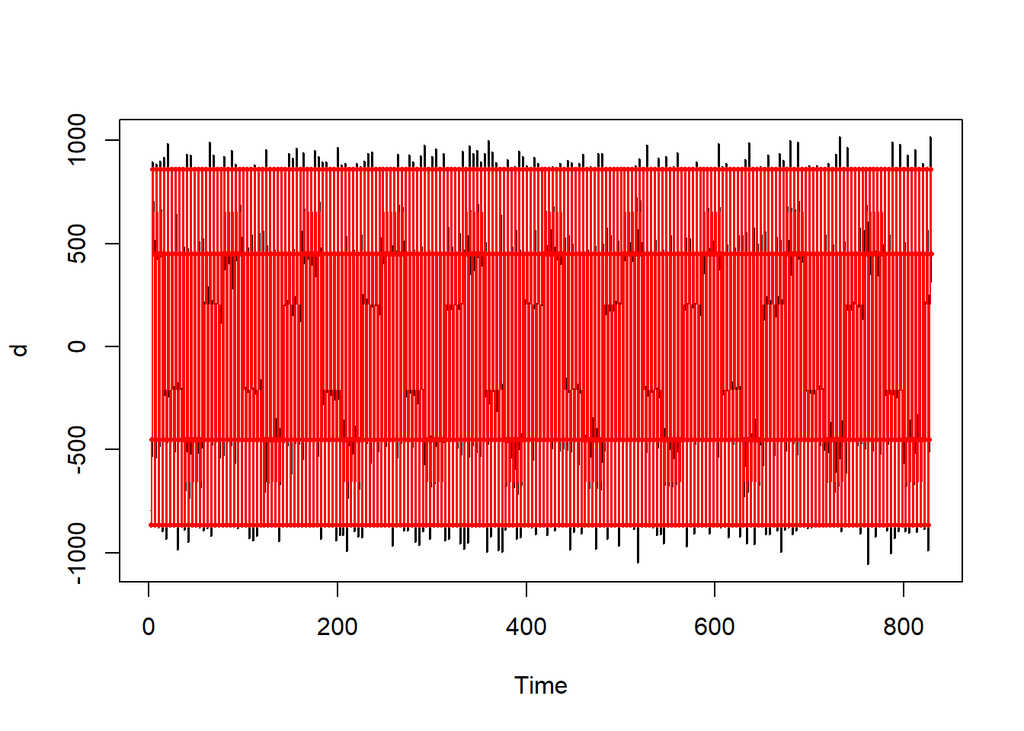

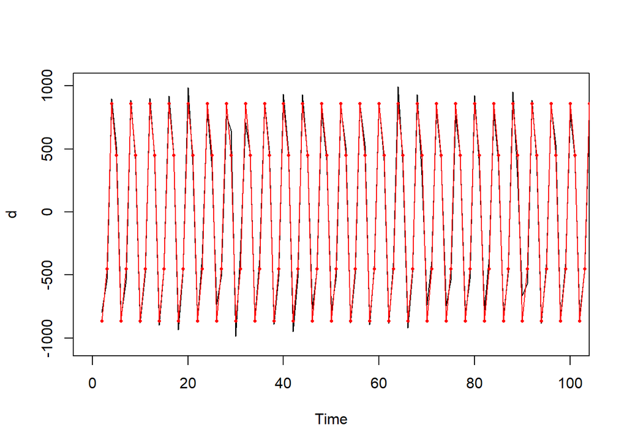

3. TOČKA: Narišite graf rezidualov in komentirajte, ali so videti stacionarni. Stacionarnost tudi preizkusite z uporabo ustreznih statističnih metod.

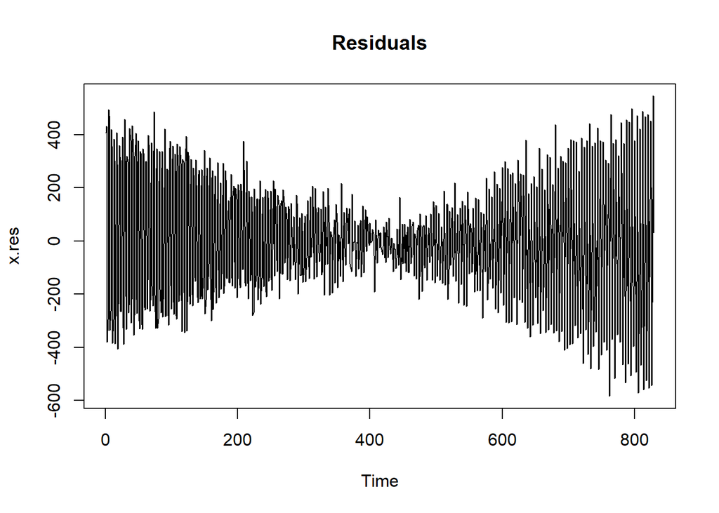

```
## [1] 0.8002073
```

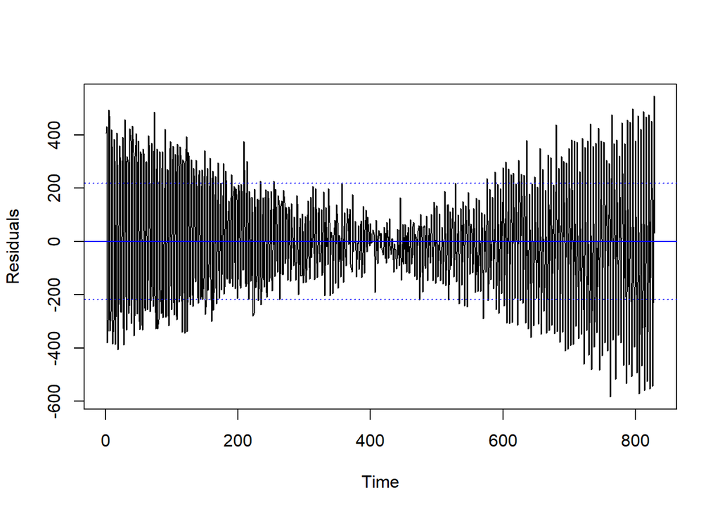

```
##
##  Augmented Dickey-Fuller Test
##
## data:  x.res
## Dickey-Fuller = -9.5751, Lag order = 9, p-value = 0.01
## alternative hypothesis: stationary
```

4. TOČKA: Na rezidualih naredite grafikona ACF in PACF in na njuni podlagi predlagajte vsaj en model vrste AR(p) ali MA(q).

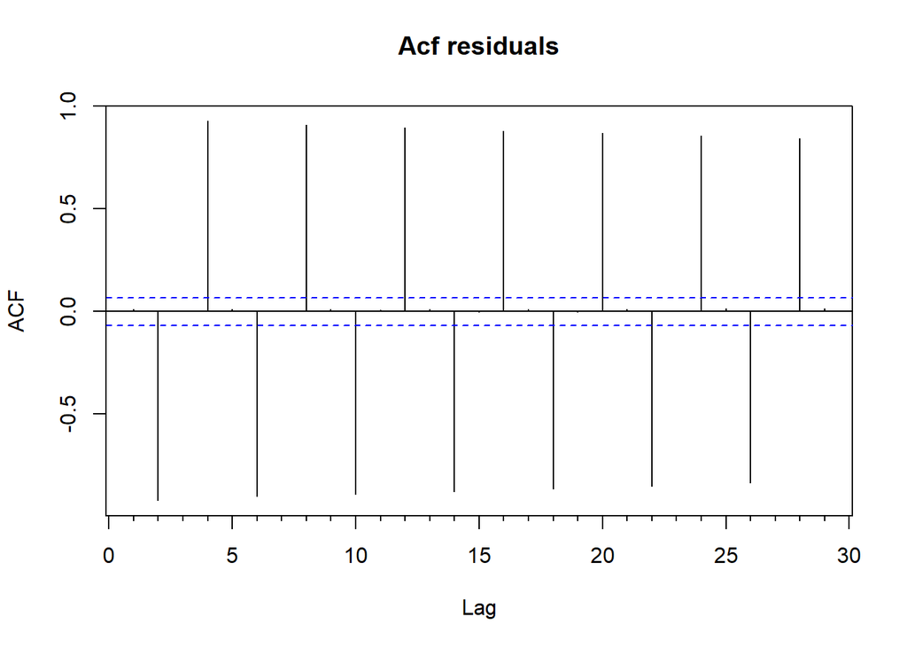

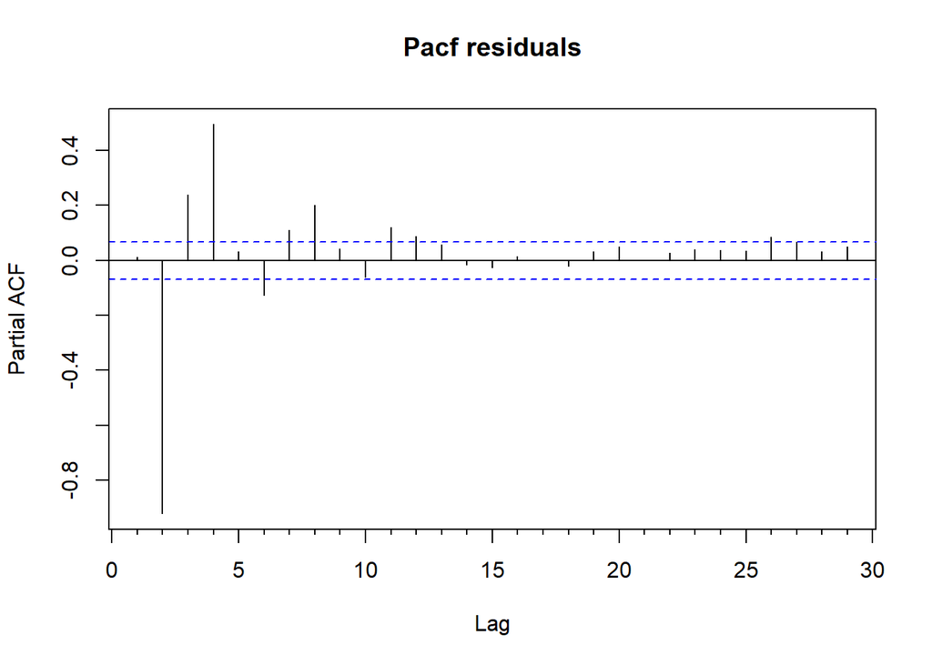

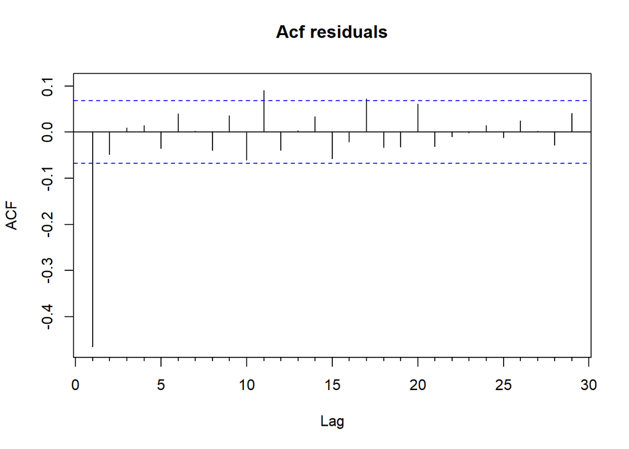

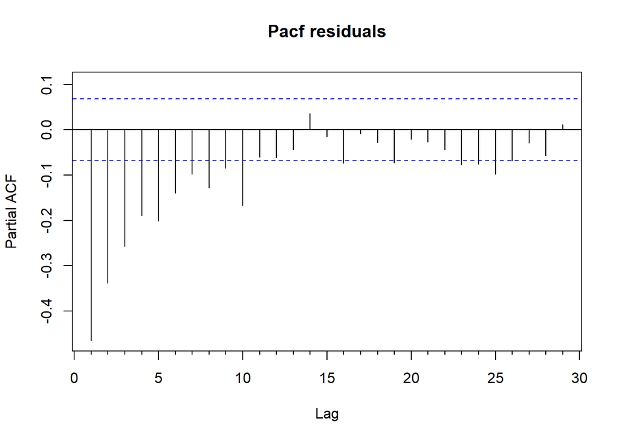

5. TOČKA: Na podlagi Yule–Walkerjevih cenilk in kriterija AIC izberite najboljši model AR(p). Primerjajte ga z najboljšim modelom ARMA(p, q) za p + q ≤ 3 po kriteriju AIC (pozor: kriterij AIC je lahko definiran drugače od postopka do postopka). Če je videti smiselno, pa namesto tega uporabite model GARCH.

```
##
## Call:
## ar(x = x.res, aic = TRUE, arg = "yule–walker")
##
## Coefficients:
##       1        2        3        4        5        6        7        8
##  0.0888  -0.3843   0.0673   0.2927   0.0516  -0.0471   0.0642   0.1298
##       9       10       11       12       13
##  0.0699  -0.0419   0.1325   0.0825   0.0568
##
## Order selected 13  sigma^2 estimated as  4738
```

```
##
## Call:
## arima(x = x.res, order = c(3, 0, 0))
##
## Coefficients:
##          ar1      ar2     ar3  intercept
##       0.2530  -0.9390  0.2552    -0.8564
## s.e.  0.0337   0.0123  0.0339     1.9033
##
## sigma^2 estimated as 6139:  log likelihood = -4793.95,  aic = 9597.9
```

[output not shown]

```
## [1] 11109.16
```

6. TOČKA: Izberite »optimalni« model in ocenite vse njegove parametre.

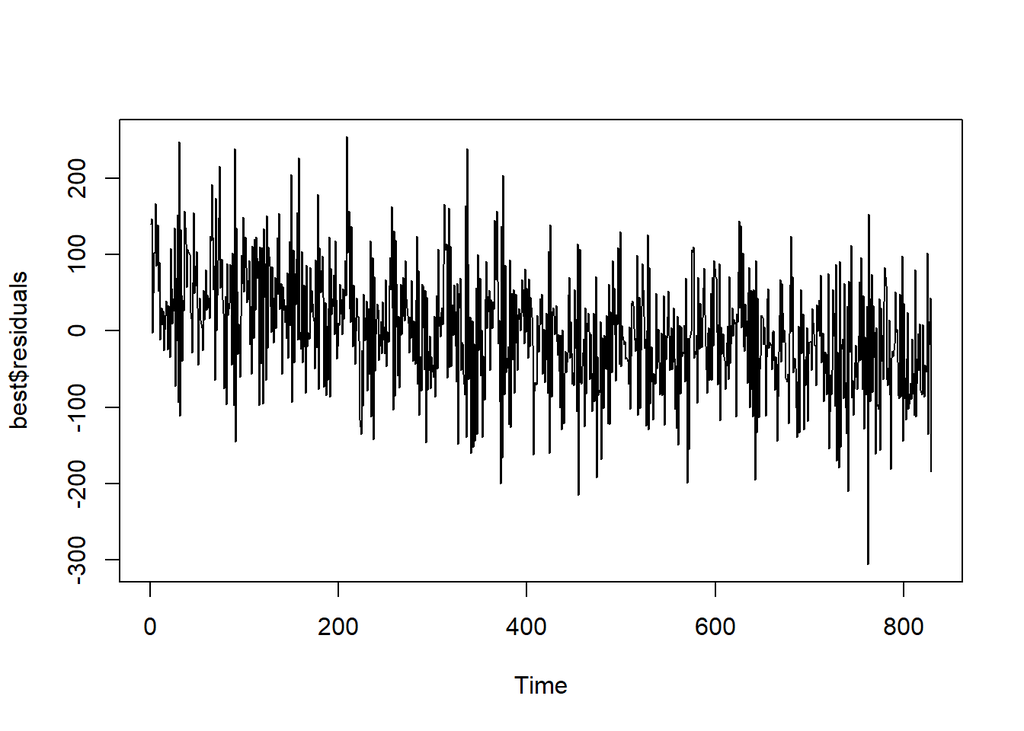

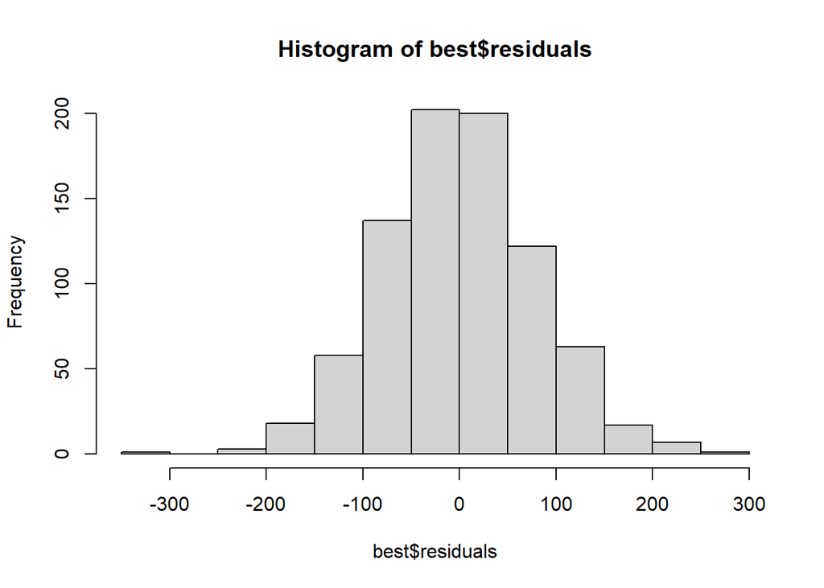

```
##
##  Shapiro-Wilk normality test
##
## data:  best$residuals
## W = 0.99833, p-value = 0.615
```

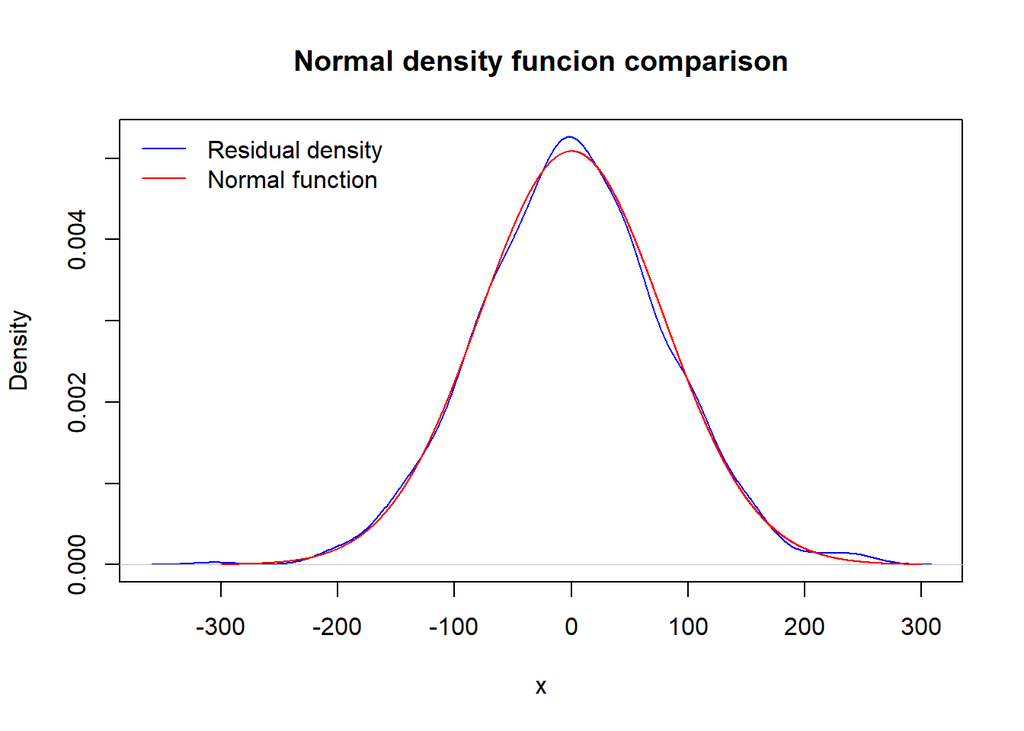

7. TOČKA: Oglejte si ostanke po vašem modelu in komentirajte, ali so videti kot beli šum. Primerjajte njihovo porazdelitev z normalno.

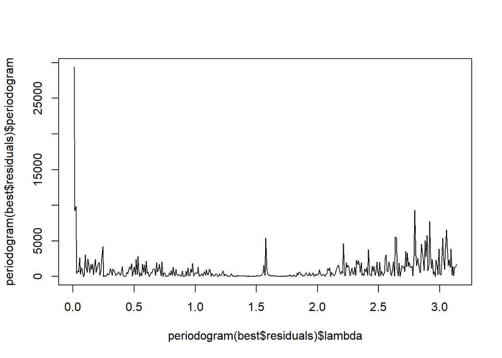

```
##
##  Box-Pierce test
##
## data:  x.res
## X-squared = 0.10581, df = 1, p-value = 0.745
```

```
##
##  Box-Ljung test
##
## data:  x.res
## X-squared = 0.1062, df = 1, p-value = 0.7445
```

8. TOČKA: Z uporabo izbranega modela in pod predpostavko normalnosti z R-ovo funkcijo predict konstruirajte 90% napovedni interval za naslednjo vrednost. Ne pozabite vračunati tudi odstranjenega trenda in sezonskosti.

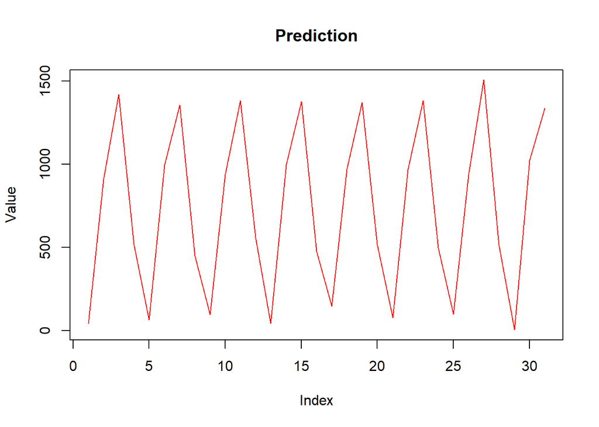

9. TOČKA: Dobljeni napovedni interval primerjajte z napovednim intervalom, ki bi ga dobili, če bi naivno privzeli, da so podatki kar Gaussov beli šum – pred in po odstranitvi trenda in sezonskosti.

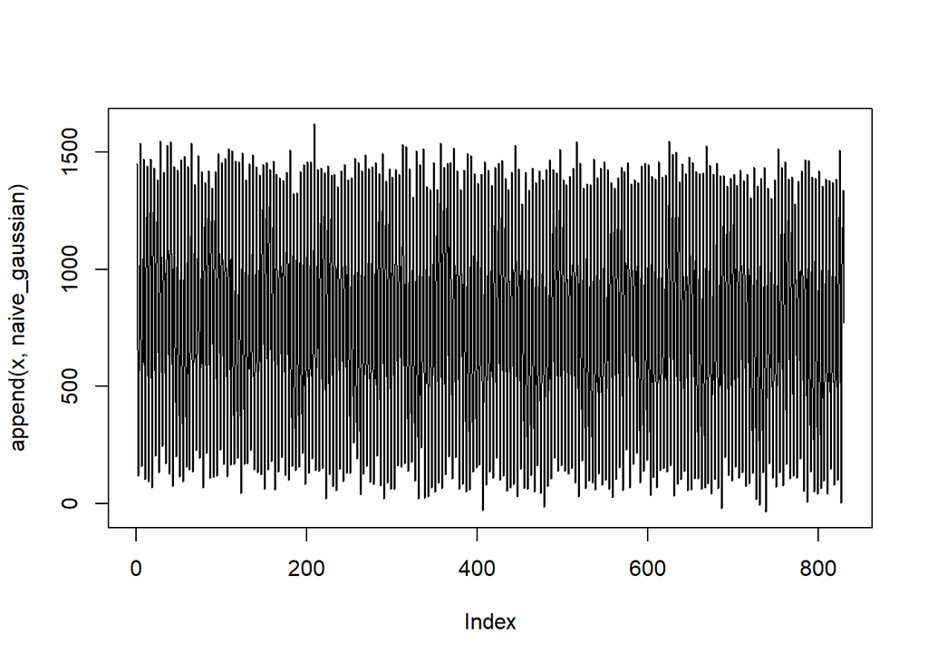

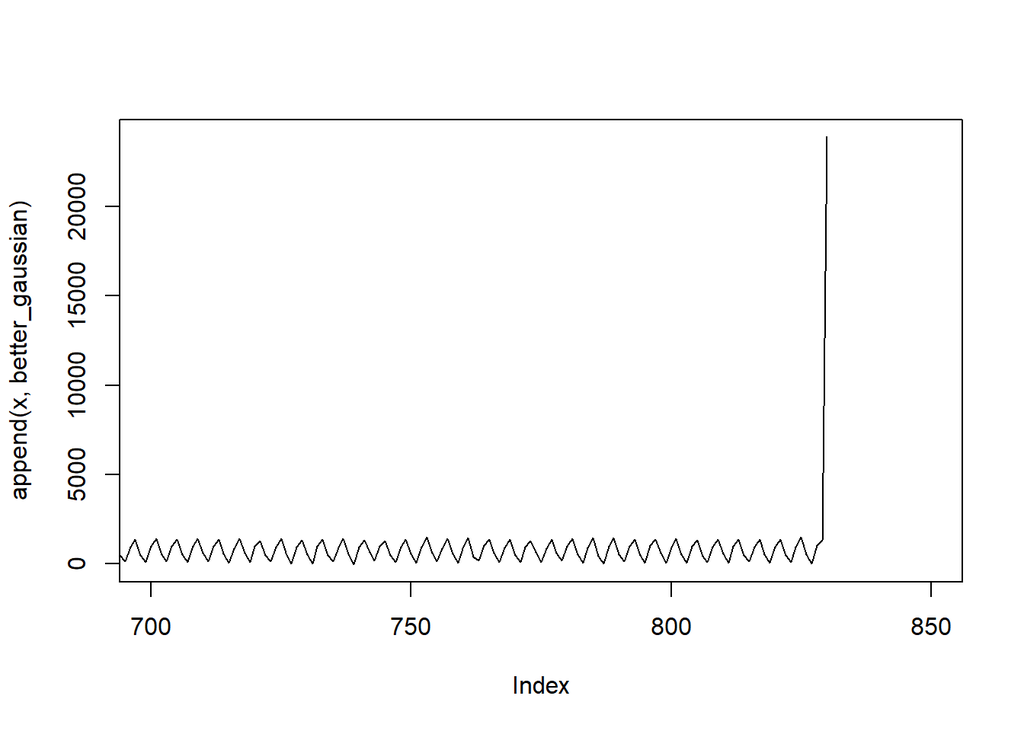

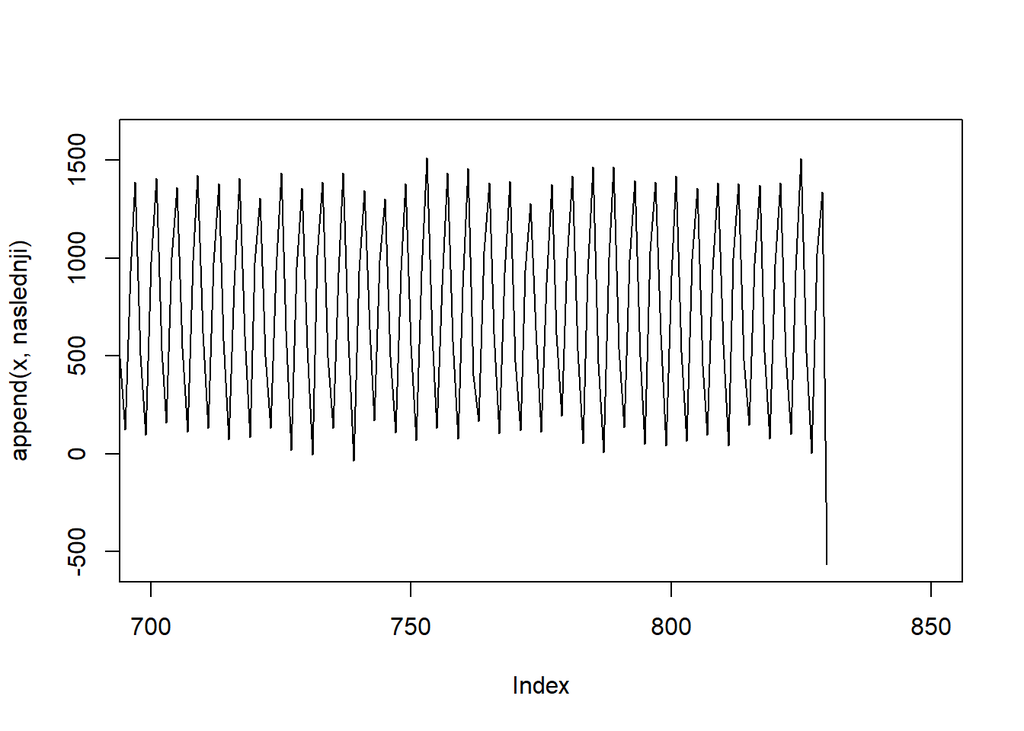

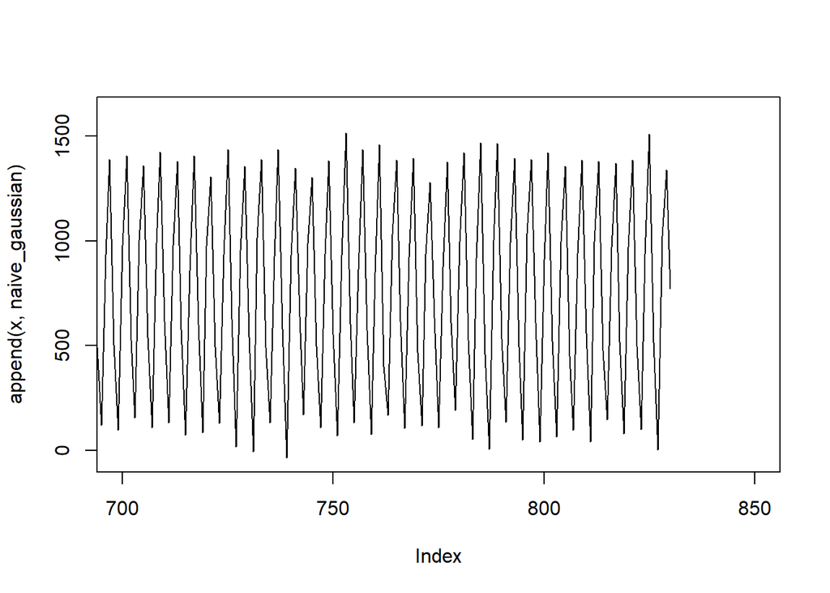

[figure not shown]